# Tarea 5

Franco Ahumada, Ignacio Duran, Benjamin Aracena

7/12/2018

##**Pregunta 1**

*Se ejecuto por GitHub*.

##**Pregunta 2**

**Retornos, Graficos y Test de Normalidad Apple**

```
## $Retorno_variación
##           date         close
## 1   2000-01-01 -0.0107271696
## 2   2000-02-01  0.1021633768
## 3   2000-03-01  0.1454927823
## 4   2000-04-01 -0.0844095596
## 5   2000-05-01 -0.3273272627
## 6   2000-06-01  0.2813453563
## 7   2000-07-01 -0.0251798580
## 8   2000-08-01  0.2111802435
## 9   2000-09-01 -0.5800202947
## 10  2000-10-01 -0.2669791475
## 11  2000-11-01 -0.1511257980
## 12  2000-12-01 -0.1250002059
## 13  2001-01-01  0.4537816471
```

[output cut: 440 more lines]

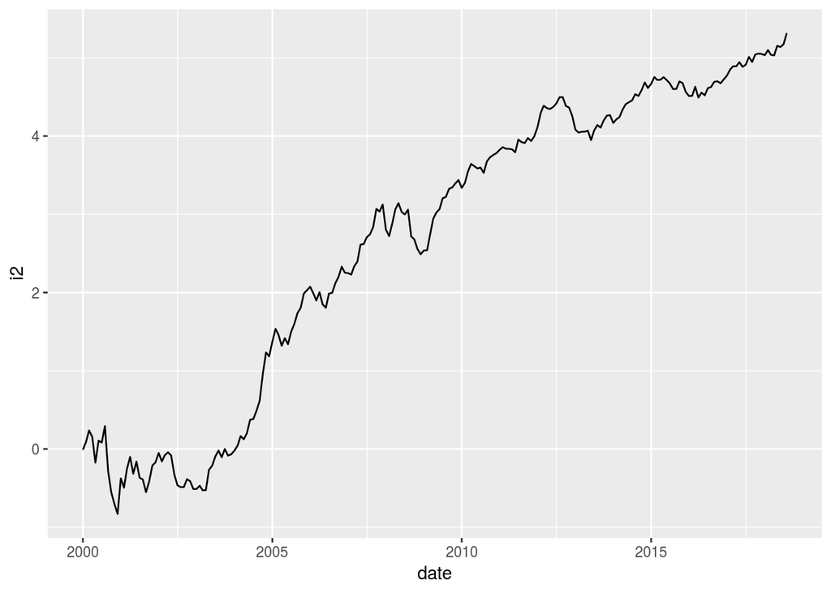

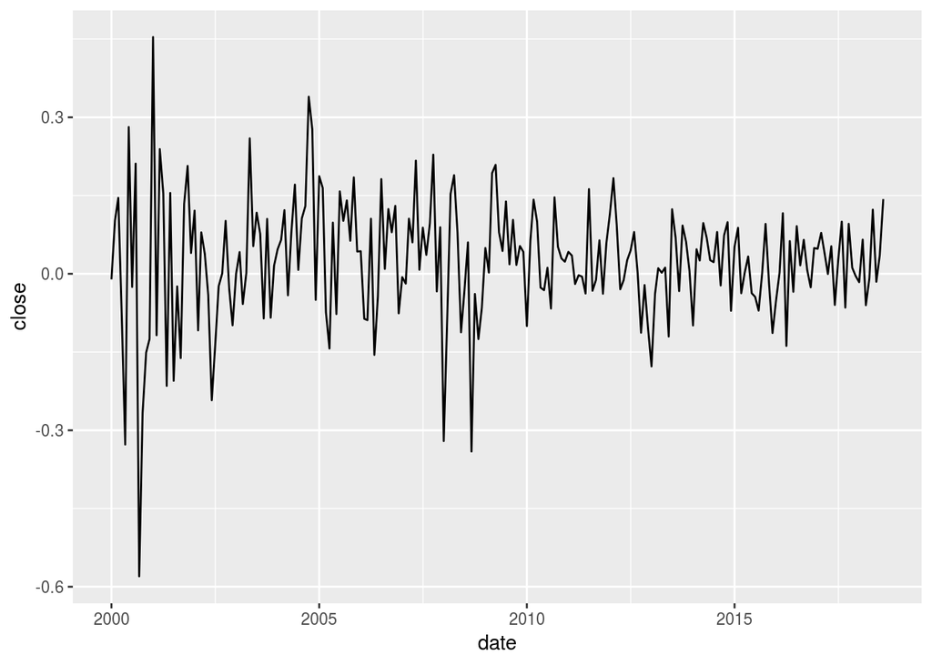

```
##
## $Jarque_Bera
## [1] "Se rechaza la hipotesis nula"
```

**Retornos, Graficos y Test de Normalidad Microsoft**

```
## $Retorno_variación
##           date         close
## 1   2000-01-01 -0.1661341853
## 2   2000-02-01 -0.0926395939
## 3   2000-03-01  0.1854951185
## 4   2000-04-01 -0.2614162806
## 5   2000-05-01 -0.1415094340
## 6   2000-06-01  0.2427184466
## 7   2000-07-01 -0.1239215686
## 8   2000-08-01 -0.0017873101
## 9   2000-09-01 -0.1383928571
## 10  2000-10-01  0.1384297521
## 11  2000-11-01 -0.1624087591
## 12  2000-12-01 -0.2529601722
## 13  2001-01-01  0.3838526912
```

[output cut: 440 more lines]

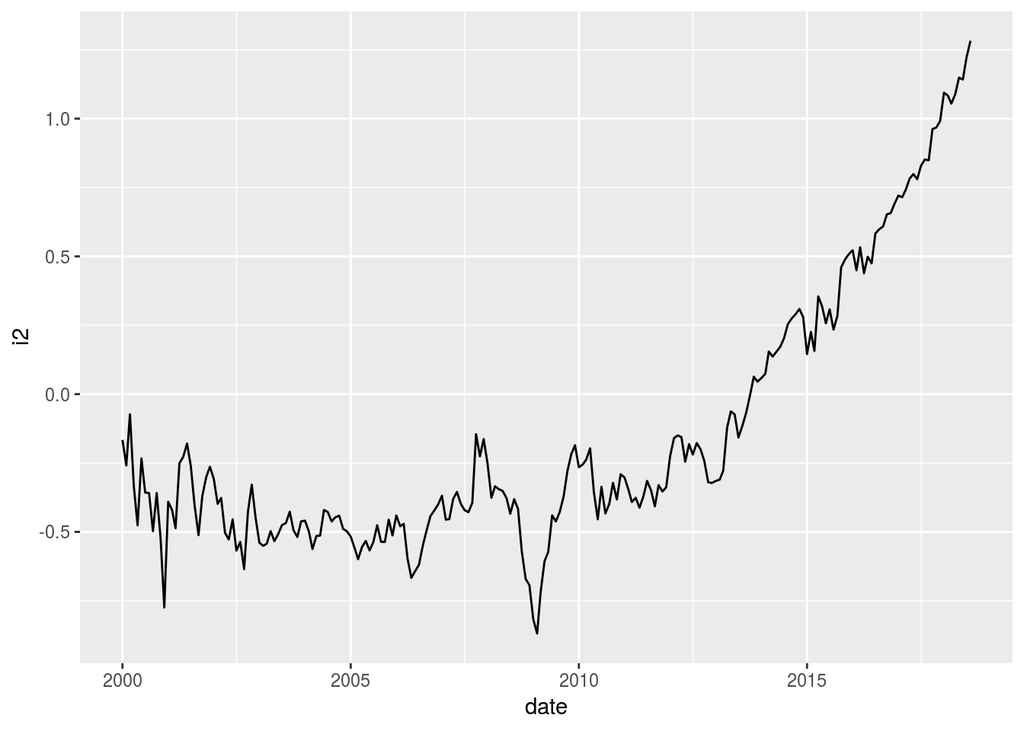

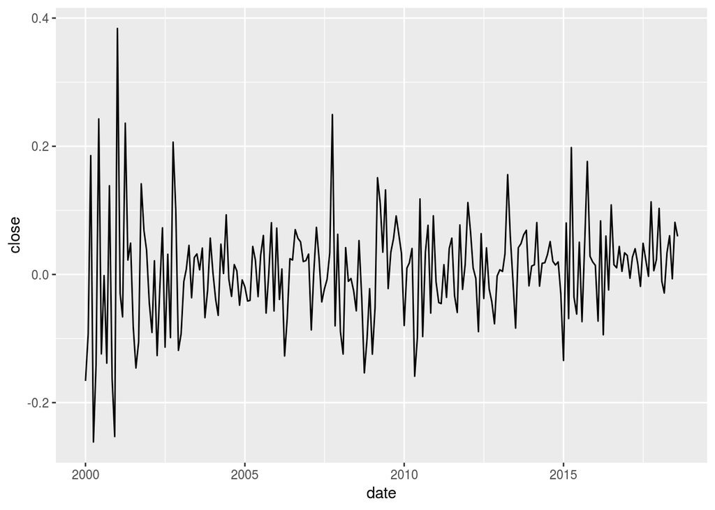

```
##
## $Jarque_Bera
## [1] "Se rechaza la hipotesis nula"
```

**Pregunta Numero 3**

Podemos ver que en el modelo que no que omite la variable relevante no hay presencia de sesgo ya que el valor esperado del estimador b1 es igual a 2.5 por lo que el estimador es insesgado. por otro lado podemos ver que para el modelo que omite la variable relevante el valor esperado del estimador esta alejado del valor del parametro poblacional por lo que podemos ver presencia de sesgo.

Tambien podemos notar que en el modelo que omite la variable relevante a medida que la muestra aumenta de tamaño el sesgo NO desaparece, sin embargo, la varianza del estimador disminuye.

**3.A**

```
##       X1       X2       X3       X4       X5       X6       X7       X8
## 3.225128 3.213405 3.243131 3.324891 2.497820 2.498969 2.499294 2.499943
```

```
##          X1          X2          X3          X4          X5          X6
## 0.026138828 0.008278822 0.002030899 0.001032683 0.036716421 0.013773312
##          X7          X8
## 0.003226795 0.001668959
```

**3.B**

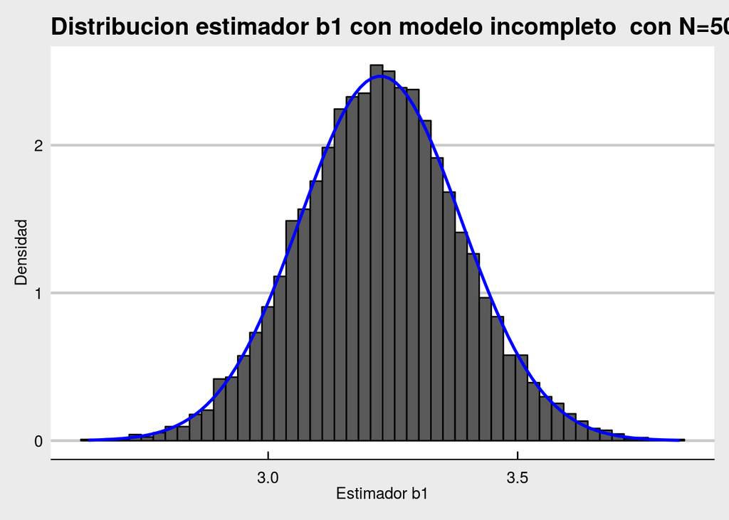

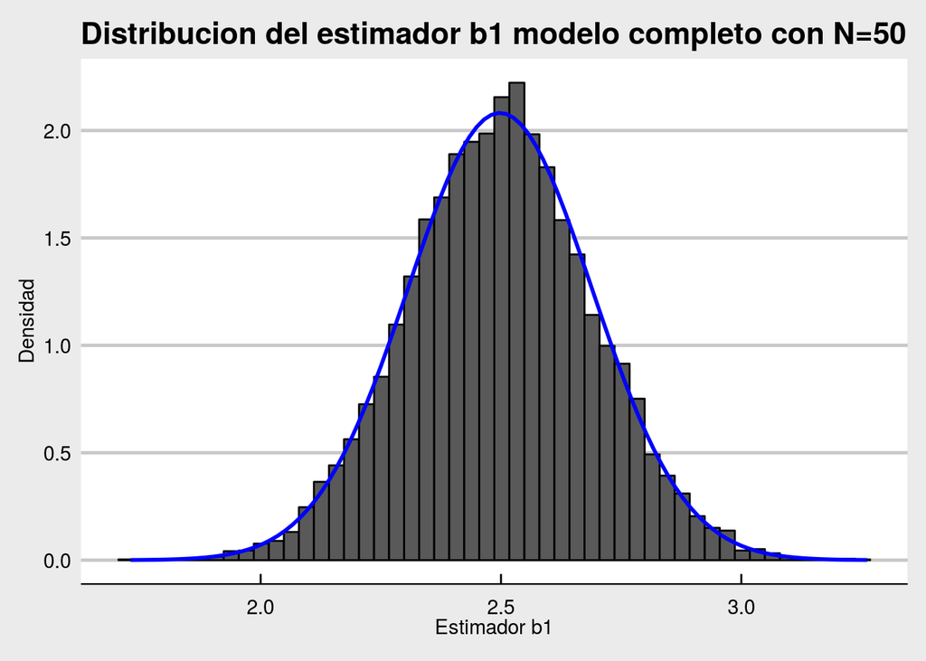

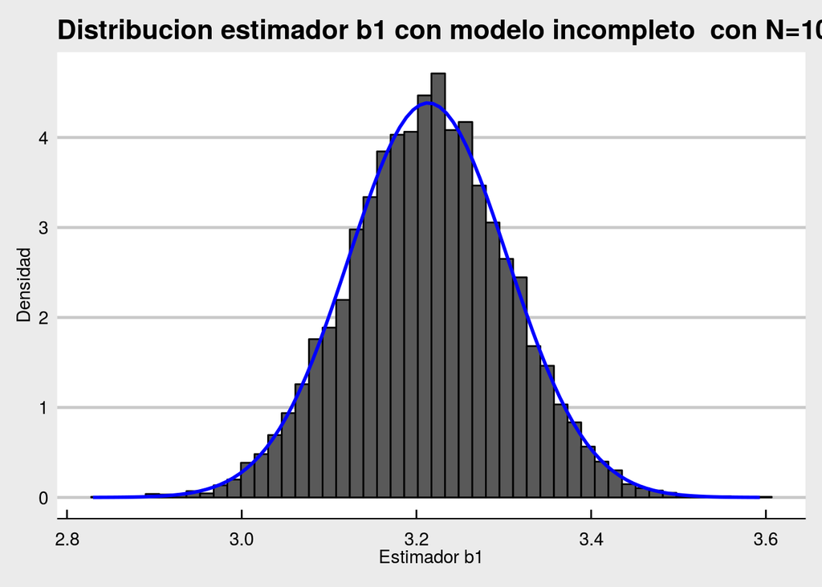

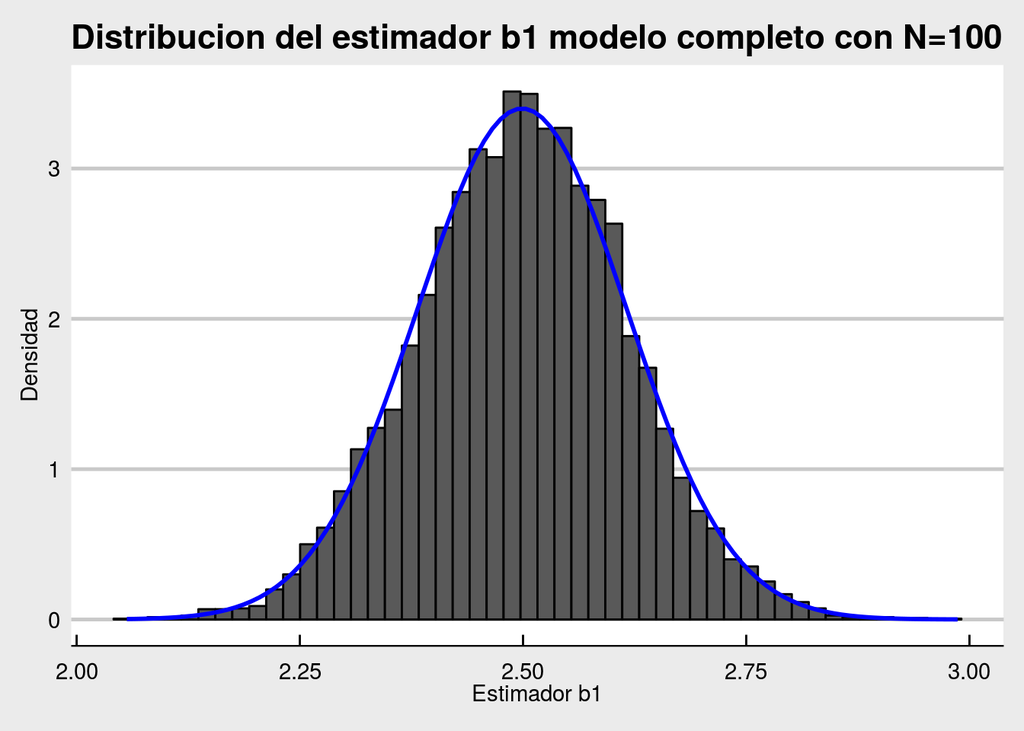

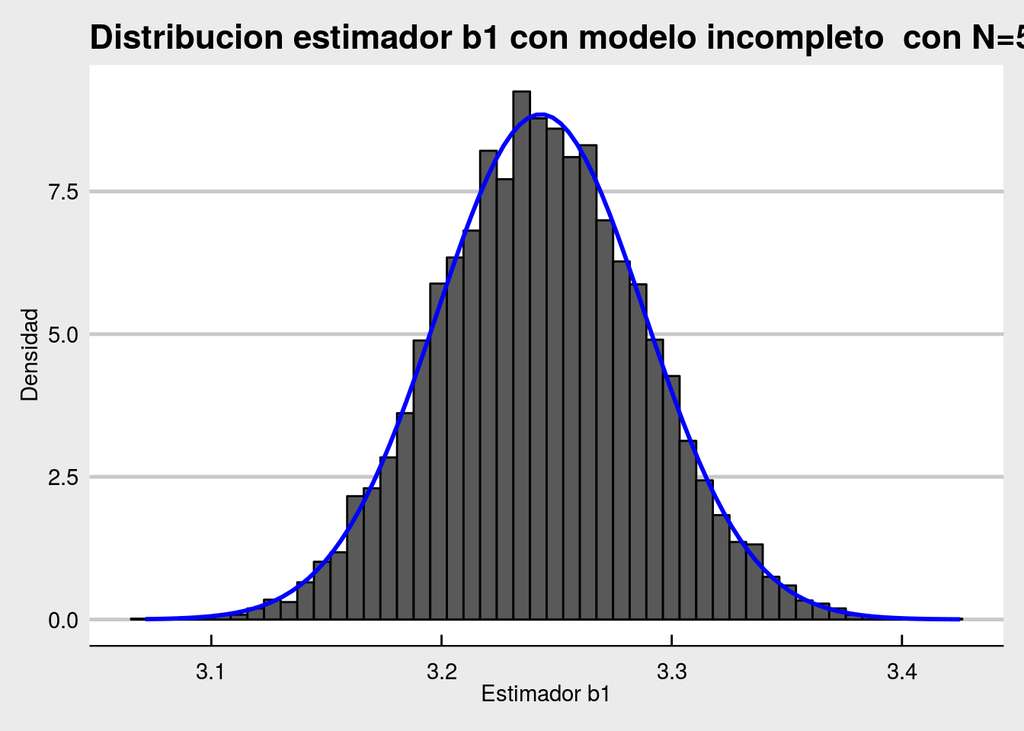

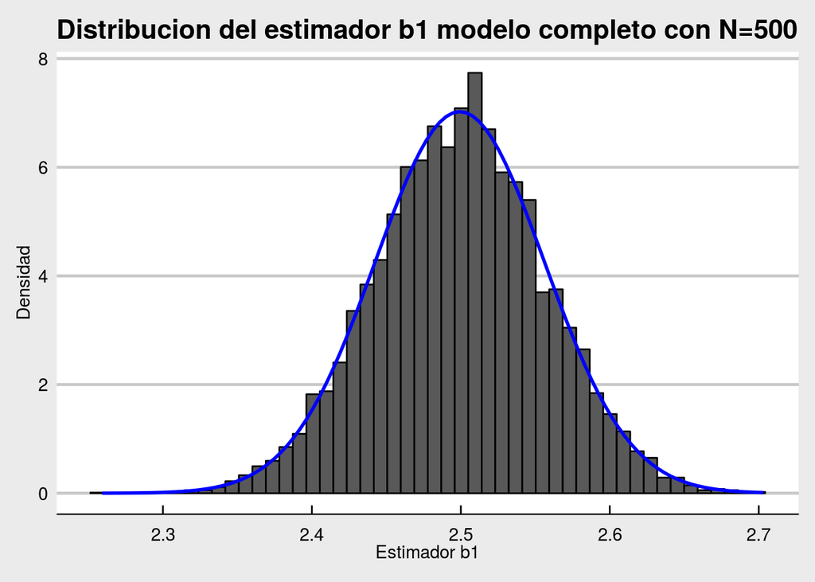

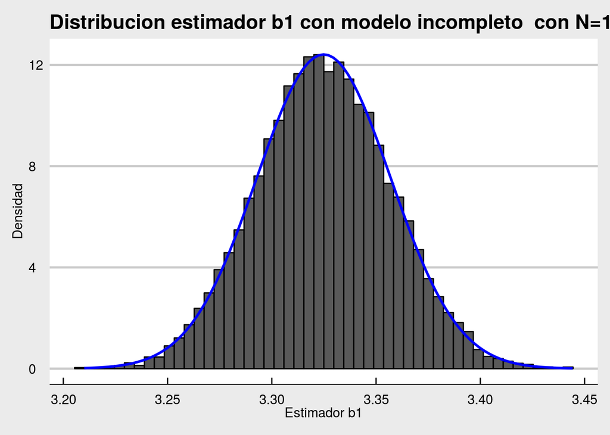

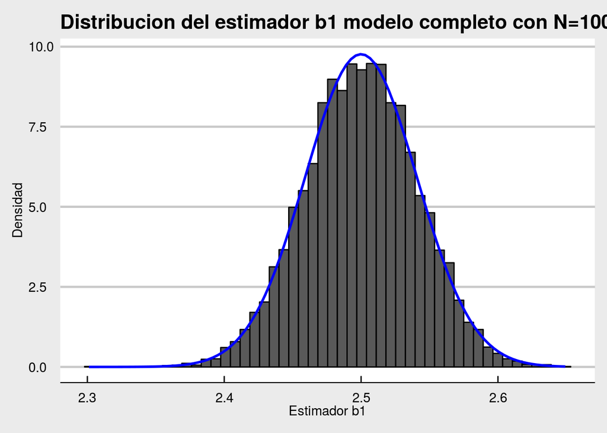

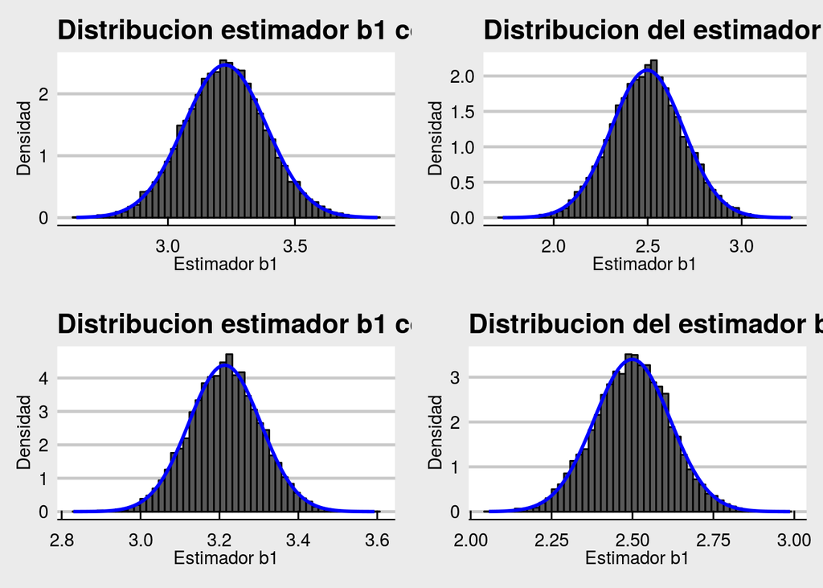

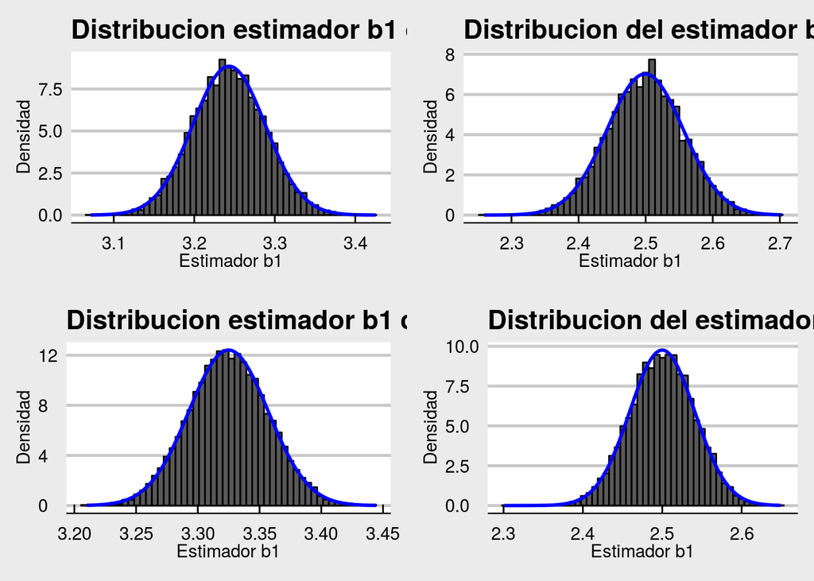

```
##       X1       X2       X3       X4       X5       X6       X7       X8
## 2.519392 2.469006 2.490529 2.504588 2.498445 2.498659 2.499558 2.500188
```

```
##          X1          X2          X3          X4          X5          X6
## 0.026138828 0.008278822 0.002030899 0.001032683 0.026238448 0.008421428
##          X7          X8
## 0.002033842 0.001033031
```

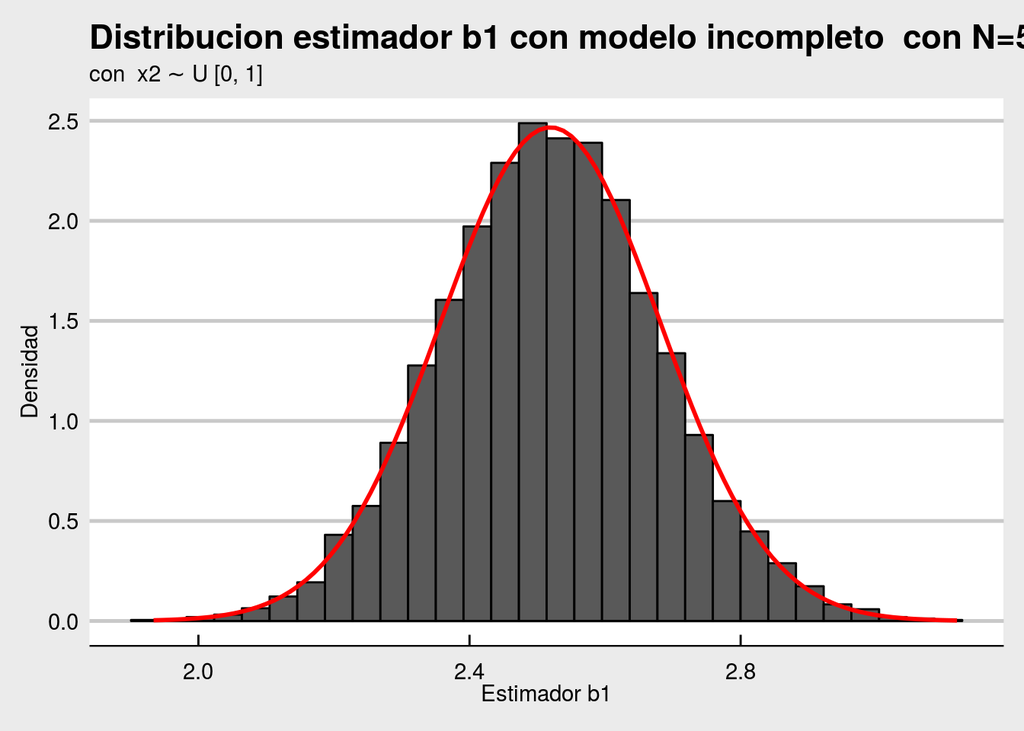

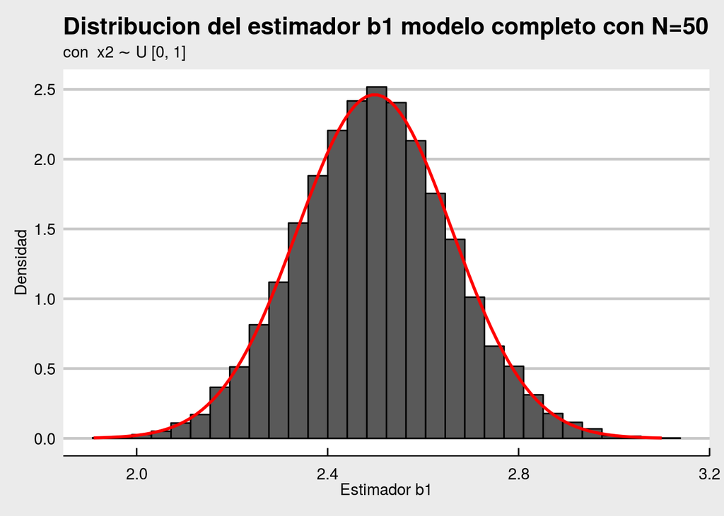

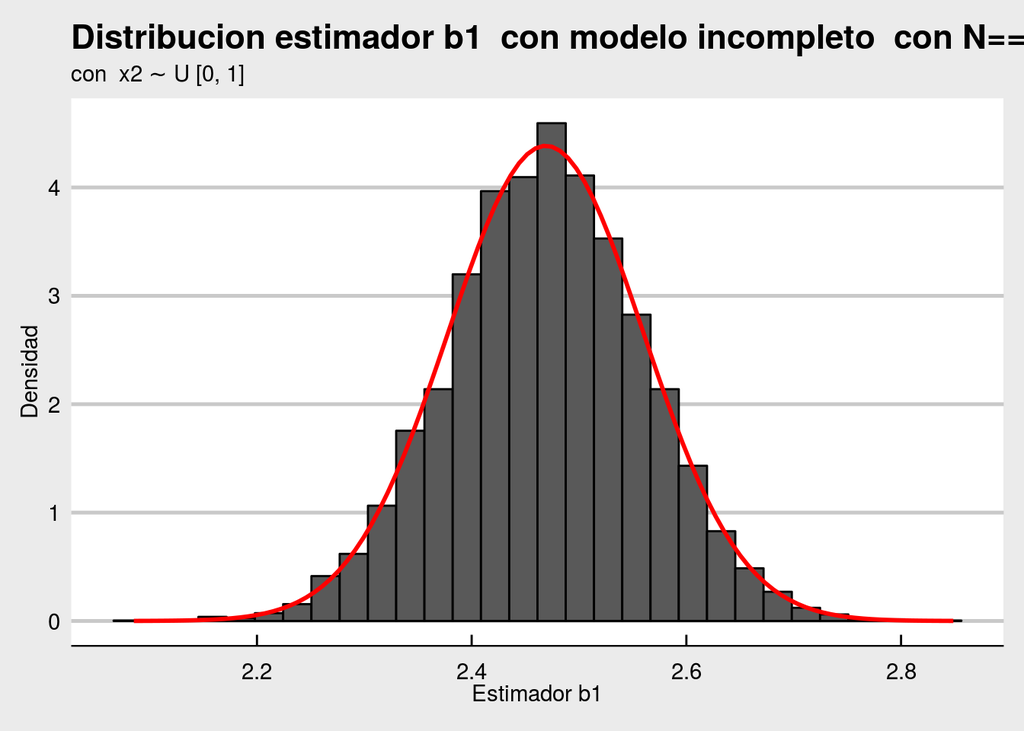

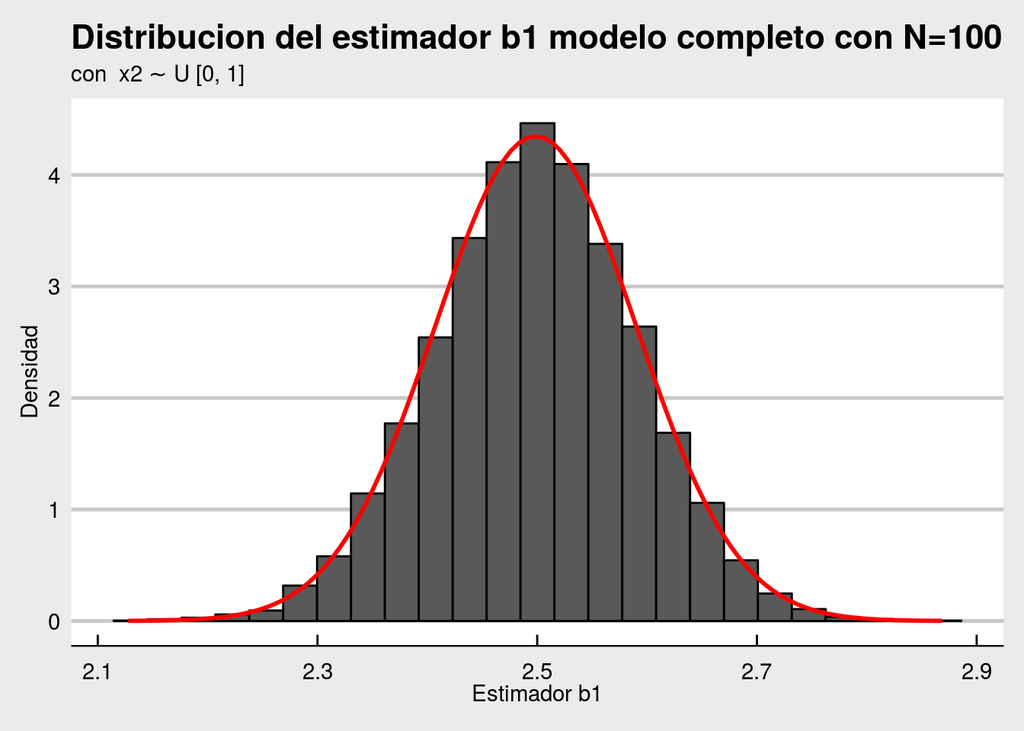

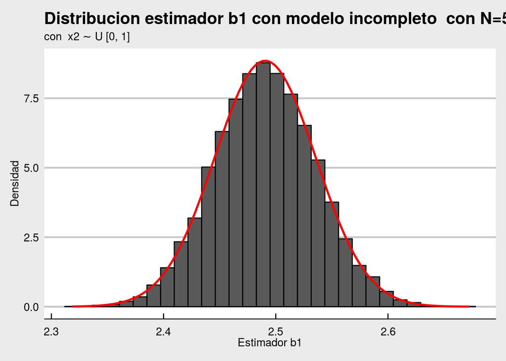

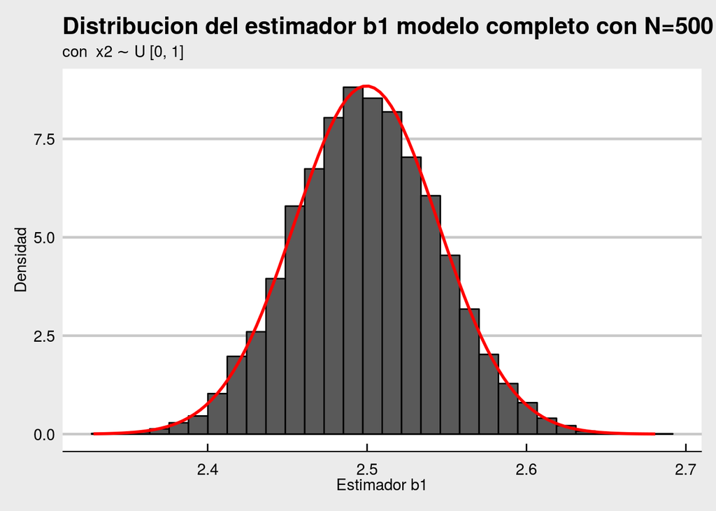

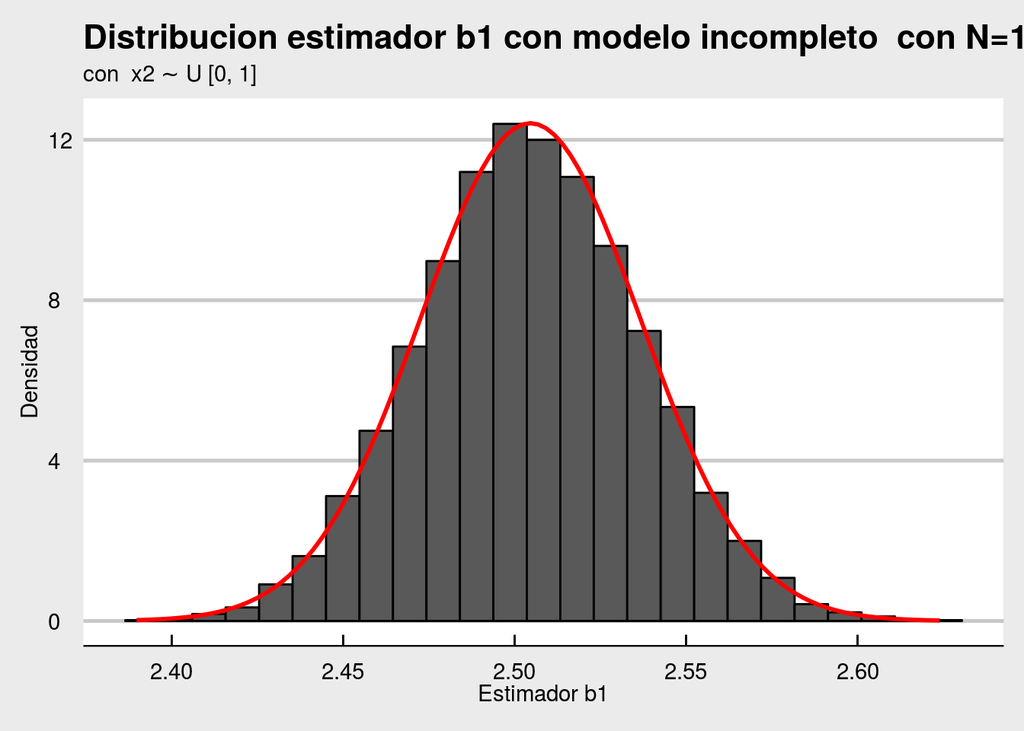

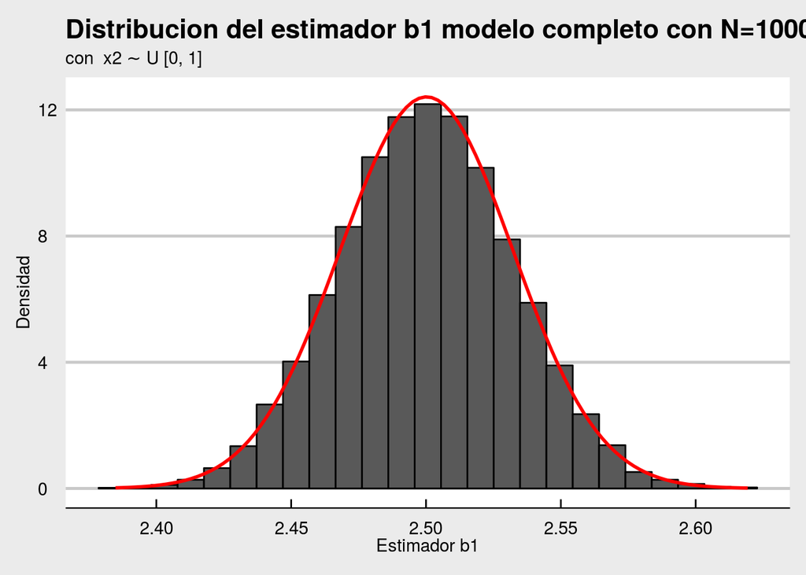

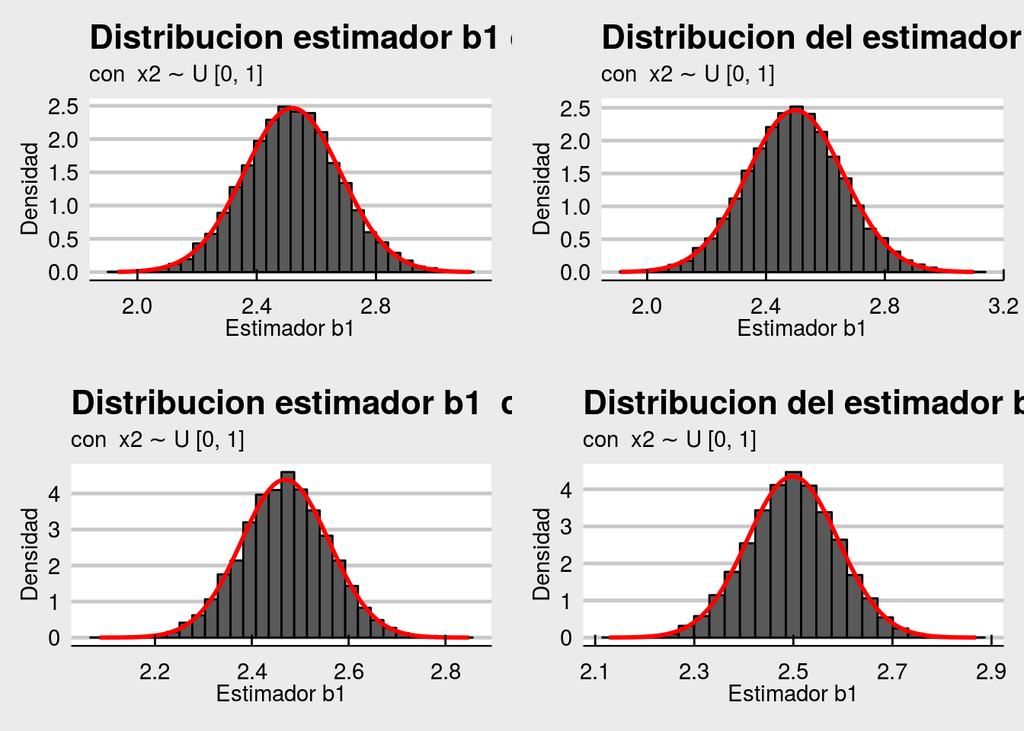

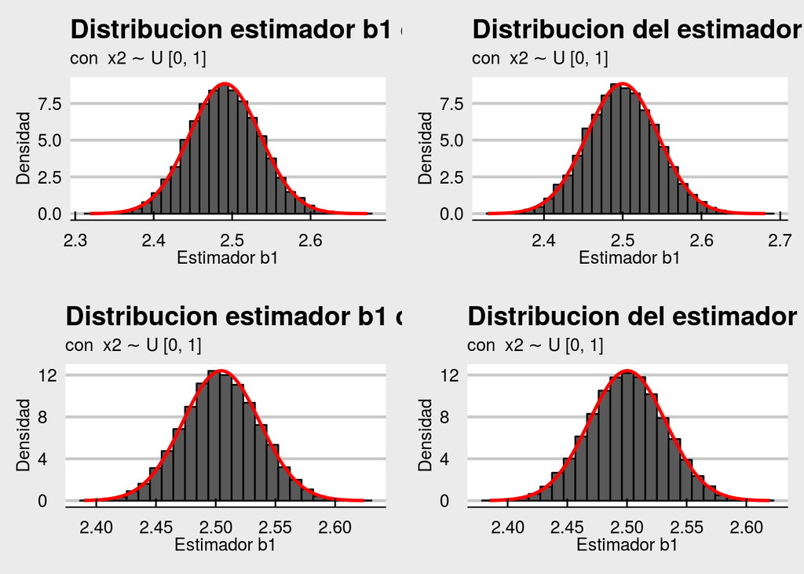